# Вредоносные программы. Трояны

Основы информационной безопасности

Федорова Анжелика Игоревна

## Актуальность

Троянские программы представляют высокую опасность как для обычного ползователя интернета, так и для крупных организаций, поскольку они могут незаметно “прокрасться” в систему и завладеть важными данными или нанести непоправимый ущерб устройству.

## Цели и задачи

Цель доклада: дать определение троянов, рассказать об их видать и дать рекомендации по борьбе с ними.

## История термина

Термин впервые появился в докладе ВВС США в 1974 году, в котором рассматривались потенциальные способы взлома компьютерных систем. Иногда такие угрозы называются «троянскими вирусными программами», но это не совсем верная формулировка. Трояны распространяются под маской полезного приложения или контента, но на деле несут вредоносную нагрузку. Лучше всего рассматривать троянские программы как способ доставки вредоносного ПО на устройство жертвы.

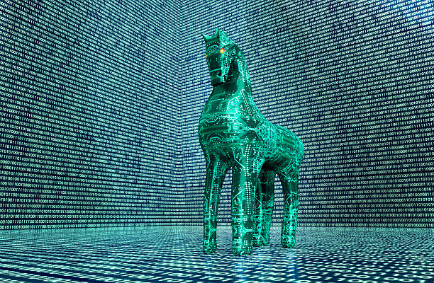

рис1

## Масштаб проблемы

Каждый месяц продукты «Лаборатории Касперского» блокируют десятки тысяч вредоносных атак на Android-устройства, целью которых является кража денег со счетов пользователей. Относительно общего количества атак это на самом деле немного: в Австралии за первый квартал было атаковано 0,81% всех пользователей, и это самый высокий показатель. Банковские трояны на десктопах встречаются чаще — детектируются у 1–3% пользователей в зависимости от страны. Внимание к таким вредоносным программам обусловлено немедленными и чувствительными финансовыми потерями, в случае успешного заражения. Посмотрим на список самых популярных зловредов для кражи денег на Android:

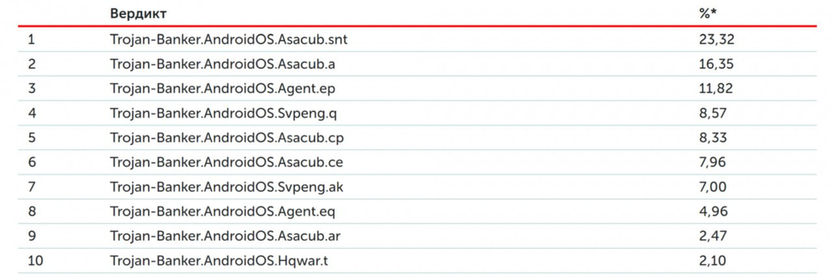

рис2

## Виды троянов

Наиболее распространены следующие виды троянов: Клавиатурные шпионы (Trojan-SPY) - трояны, постоянно находящиеся в памяти и сохраняющие все данные поступающие от клавиатуры с целью последующей передачи этих данных злоумышленнику.

Похитители паролей (Trojan-PSW) - трояны, также предназначенные для полу- чения паролей, но не использующие слежение за клавиатурой. Обычно в таких троянах реализованы способы извлечения паролей из файлов, в которых эти пароли хранятся c различными приложениями

## Виды троянов

Утилиты удаленного управления (Backdoor) - трояны, обеспечивающие полный удаленный контроль над компьютером пользователя

Анонимные smtp-сервера и прокси (Trojan-Proxy) - трояны, выполняющие функции почтовых серверов или прокси и использующиеся в первом случае для спам-рассылок, а во втором для заметания следов хакерами

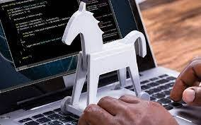

рис3

## Способы защиты от троянов

Вот несколько рекомендаций, которые помогут вам защитить своё устройство от проникновения троянов вирусов:

1. Не открывайте электронные письма с незнакомых адресов. Если в письме есть вложение, то подумайте, нужно ли вам его открывать. Такие документы и ссылки часто содержат в себе трояны.
2. Регулярно обновляйте программы и приложения, которые установлены на ваших устройствах. Обновления призваны исправить уязвимые места в ПО и минимизировать риск проникновения вируса.

## Способы защиты от троянов

3. Не переходите по незнакомым и сомнительным ссылкам. Они могут приве- сти вас на поддельный сайт, который установит на ваше устройство вредо- носное программное обеспечение в фоновом режиме.
4. Загружайте любые программы только из проверенных источников.
5. Время от времени проверяйте систему на наличие вредоносных программ при помощи антивирусного ПО.

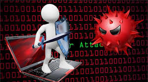

рис4

## Вывод

Таким образом, трояны являются серьезной угрозой безопасности пользова- телей и крупных предприятий. Поэтому мы должны быть осведолены о них и предпринять необходимые меры защиты и борьбы с ними.

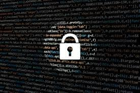

рис4

## Итоговый слайд

Спасибо за внимание!